# Assignment 9

Noah Christensen

# Packages

Here I’m loading the packages I will use

```r
library(tidyverse)
library(janitor)
library(GGally)
library(modelr)
library(easystats)
library(huxtable)
library(MASS)
```

# Reading in data

Let’s load in the data and make sure the 1’s and 0’s read as TRUE and FALSE

```r
df <- read.csv("../../Data/GradSchool_Admissions.csv") %>%
  janitor::clean_names()

df <- df %>%
  mutate(admit = as.logical(admit))
```

# Pairs

I wanted to view pairs with a quick glance

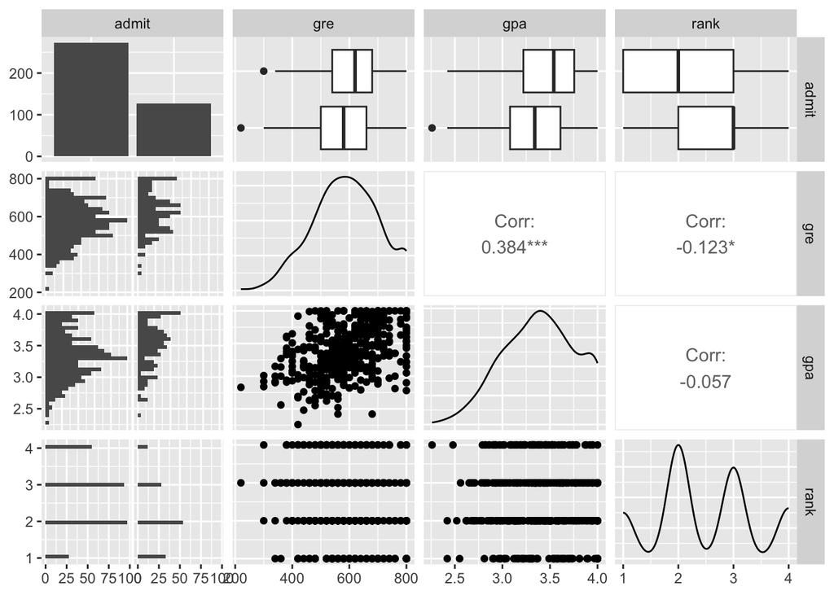

```r
ggpairs(df)
```

# Plots

Let’s view some quick plots

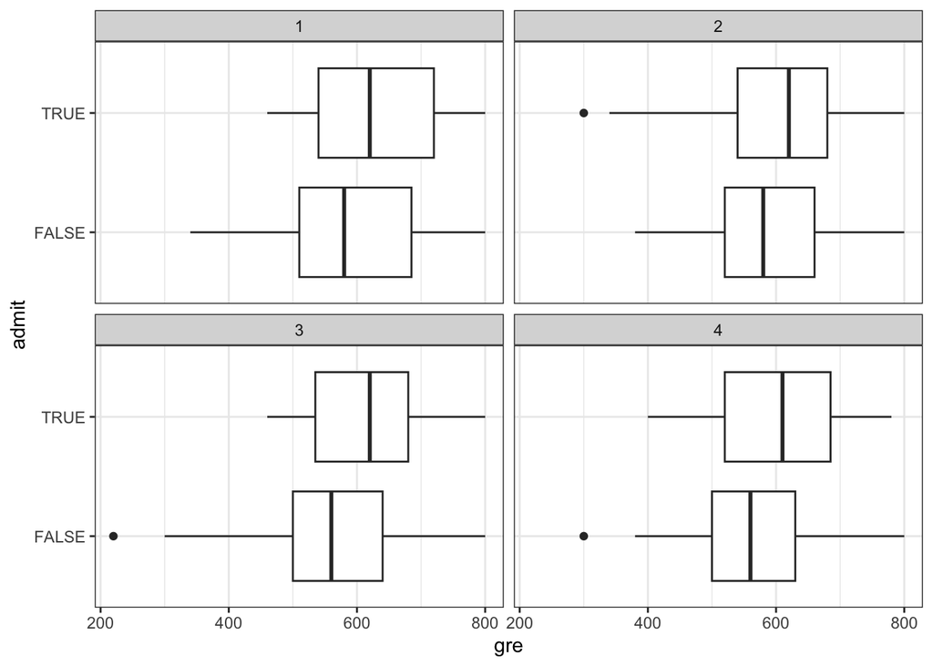

```r
df %>%
  ggplot(aes(x=gre,y=admit)) +
  geom_boxplot() +
  facet_wrap(~rank) +
  theme_bw()
```

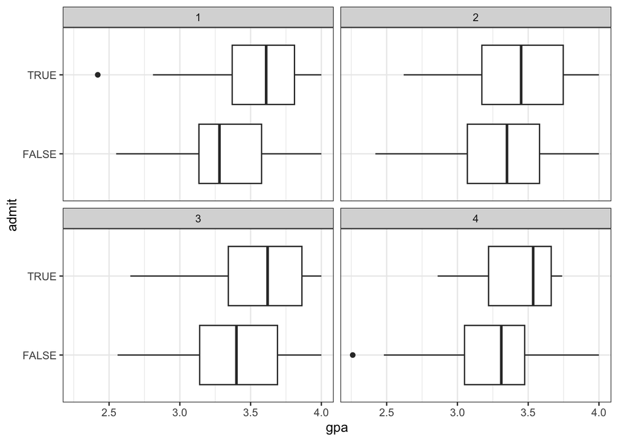

```r
df %>%
  ggplot(aes(x=gpa,y=admit)) +
  geom_boxplot() +
  facet_wrap(~rank) +
  theme_bw()
```

These plots show a distinct inclination towards higher gpa, higher gre, and a higher rank.

# Models

Now to create some models. I chose to make the first three super simple and only based on one variable. I made the fourth and fifth model a little more complicated.

```r
m1 <- glm(data = df,
          admit ~ gre,
          family = 'binomial')
m2 <- glm(data = df,
          admit ~ gpa,
          family = 'binomial')
m3 <- glm(data = df,
          admit ~ rank,
          family = 'binomial')
m4 <- glm(data = df,
          admit ~ gre + gpa + rank,
          family = 'binomial')
m5 <- glm(data = df,
          admit ~ gre * gpa * rank,
          family = 'binomial')
```

# Best model

Lets see what’s the best model according to AIC values

```r
m6 <- glm(data = df,
          admit ~ .^2,
          family = 'binomial')

#feed largest most complicated model and it will find the best one
step <- stepAIC(m6)
```

```
## Start:  AIC=470.25
## admit ~ (gre + gpa + rank)^2
##
##            Df Deviance    AIC
## - gre:rank  1   456.34 468.34
## - gpa:rank  1   456.58 468.58
## <none>          456.25 470.25
## - gre:gpa   1   459.31 471.31
##
## Step:  AIC=468.34
## admit ~ gre + gpa + rank + gre:gpa + gpa:rank
##
##            Df Deviance    AIC
## - gpa:rank  1   456.60 466.60
## <none>          456.34 468.34
## - gre:gpa   1   459.33 469.33
##
## Step:  AIC=466.6
## admit ~ gre + gpa + rank + gre:gpa
##
##           Df Deviance    AIC
## <none>         456.60 466.60
## - gre:gpa  1   459.44 467.44
## - rank     1   477.85 485.85
```

```r
#best simplified model for this data set
step$formula
```

```
## admit ~ gre + gpa + rank + gre:gpa
```

```r
bestmod <- glm(data = df,
          admit ~ gre + gpa + rank + gre:gpa,
          family = 'binomial')
```

# Comparison

Now for some comparison

```r
comparison <- compare_performance(m1,m2,m3,m4,m5,bestmod,rank=TRUE)
comparison
```

| Name | Model | R2_Tjur | RMSE | Sigma | Log_loss | Score_log | Score_spherical | PCP | AIC_wt | AICc_wt | BIC_wt | Performance_Score |
| --- | --- | --- | --- | --- | --- | --- | --- | --- | --- | --- | --- | --- |
| bestmod | glm | 0.105 | 0.44 | 1 | 0.571 | -50.5 | 0.00406 | 0.612 | 0.583 | 0.579 | 0.156 | 0.594 |
| m4 | glm | 0.0989 | 0.442 | 1 | 0.574 | -50.5 | 0.00367 | 0.609 | 0.382 | 0.389 | 0.754 | 0.581 |
| m3 | glm | 0.0605 | 0.451 | 1 | 0.595 | -49 | 0.0103 | 0.593 | 0.000828 | 0.000874 | 0.0885 | 0.393 |
| m5 | glm | 0.106 | 0.44 | 1 | 0.57 | -50.6 | 0.00482 | 0.613 | 0.0345 | 0.0308 | 2.33e-05 | 0.372 |
| m2 | glm | 0.0325 | 0.458 | 1 | 0.609 | -48.2 | 0.00375 | 0.581 | 2.98e-06 | 3.14e-06 | 0.000318 | 0.232 |
| m1 | glm | 0.0339 | 0.458 | 1 | 0.608 | -48.2 | 0.00312 | 0.581 | 4.69e-06 | 4.96e-06 | 0.000502 | 0.221 |

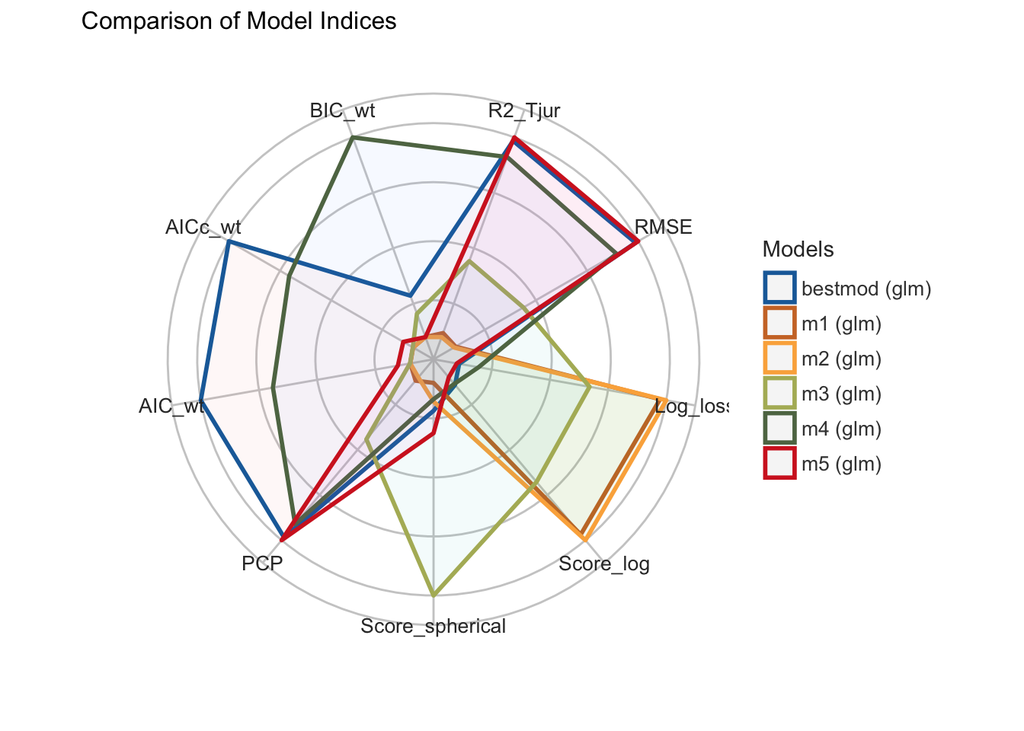

```r
comparison %>% plot
```

```r
huxreg(list("Model 1" = m1, "Model 2" = m2, "Model 3" = m3, "Model 4" = m4, "Model 5" = m5, "Best Model" = bestmod))
```

|  | Model 1 | Model 2 | Model 3 | Model 4 | Model 5 | Best Model |
| --- | --- | --- | --- | --- | --- | --- |
| (Intercept) | -2.901 *** | -4.358 *** | 0.637 * | -3.450 ** | -15.080 | -13.196 * |
|  | (0.606) | (1.035) | (0.306) | (1.133) | (16.414) | (6.046) |
| gre | 0.004 *** |  |  | 0.002 * | 0.019 | 0.019 |
|  | (0.001) |  |  | (0.001) | (0.027) | (0.010) |
| gpa |  | 1.051 *** |  | 0.777 * | 4.361 | 3.661 * |
|  |  | (0.299) |  | (0.327) | (4.845) | (1.780) |
| rank |  |  | -0.586 *** | -0.560 *** | 0.047 | -0.566 *** |
|  |  |  | (0.124) | (0.127) | (6.607) | (0.127) |
| gre:gpa |  |  |  |  | -0.005 | -0.005 |
|  |  |  |  |  | (0.008) | (0.003) |
| gre:rank |  |  |  |  | 0.000 |  |
|  |  |  |  |  | (0.011) |  |
| gpa:rank |  |  |  |  | -0.241 |  |
|  |  |  |  |  | (1.934) |  |
| gre:gpa:rank |  |  |  |  | 0.000 |  |
|  |  |  |  |  | (0.003) |  |
| N | 400 | 400 | 400 | 400 | 400 | 400 |
| logLik | -243.028 | -243.484 | -237.856 | -229.721 | -228.125 | -228.299 |
| AIC | 490.056 | 490.968 | 479.711 | 467.442 | 472.250 | 466.598 |
| *** p < 0.001; ** p < 0.01; * p < 0.05. |  |  |  |  |  |  |

# Predictions

And finally to plot some predictions

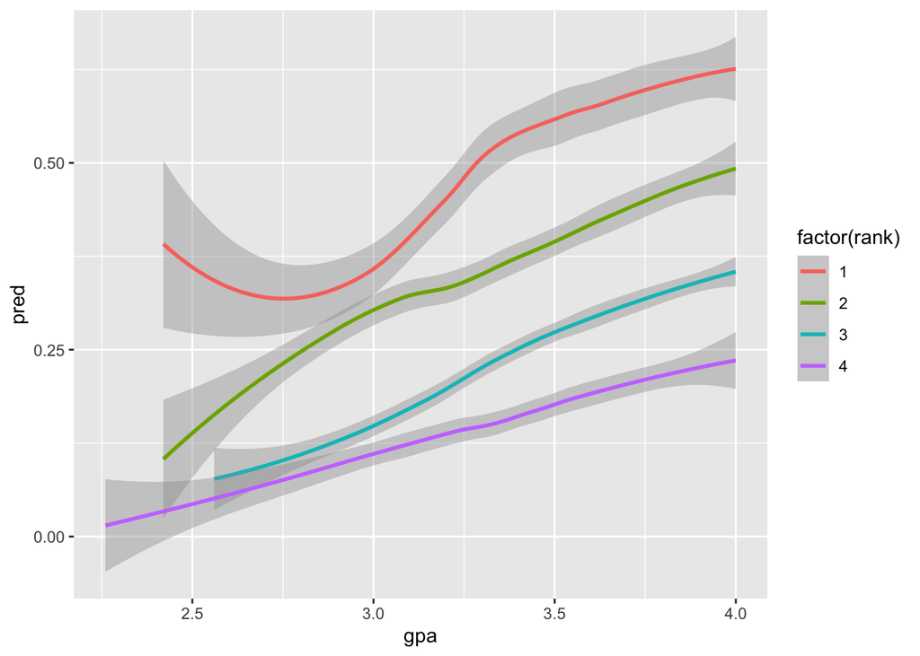

```r
add_predictions(df,bestmod,type='response') %>%
  ggplot(aes(x=gpa,y=pred,color=factor(rank))) +
  geom_smooth()
```

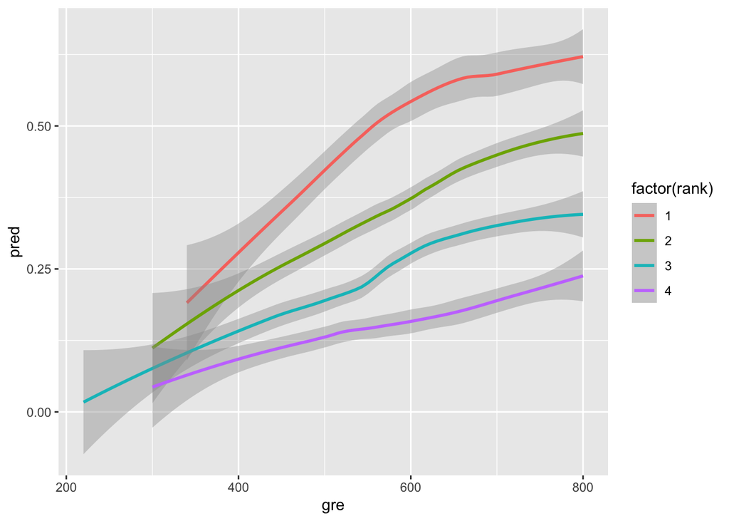

```r
add_predictions(df,bestmod,type='response') %>%
  ggplot(aes(x=gre,y=pred,color=factor(rank))) +
  geom_smooth()
```

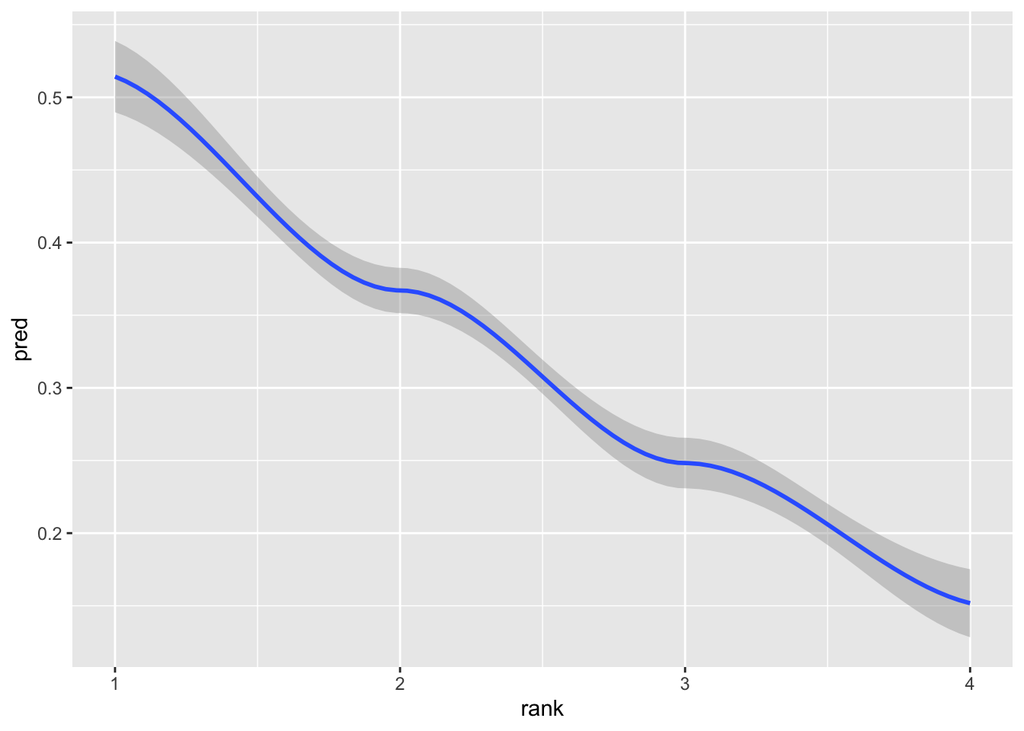

```r
add_predictions(df,bestmod,type='response') %>%
  ggplot(aes(x=rank,y=pred)) +
  geom_smooth()
```

# Conclusions

Having a gpa of 2.5 in a rank 1 school gives you better odds of getting accepted than having a 4.0 in a rank 4 school…

**Life is not fair** I guess is the conclusion haha.